# Project - Ensemble Techniques - Anis Uddin

```python
#Importing basic libraries, we will import other libraries as and when required.
import numpy as np
import pandas as pd
import matplotlib.pyplot as plt
import seaborn as sns
```

```python
Data  = pd.read_csv('Data - Parkinsons.csv')
```

```python
Data.head()
```

|  | name | MDVP:Fo(Hz) | MDVP:Fhi(Hz) | MDVP:Flo(Hz) | MDVP:Jitter(%) | MDVP:Jitter(Abs) | MDVP:RAP | MDVP:PPQ | Jitter:DDP | MDVP:Shimmer | ... | Shimmer:DDA | NHR | HNR | status | RPDE | DFA | spread1 | spread2 | D2 | PPE |
| --- | --- | --- | --- | --- | --- | --- | --- | --- | --- | --- | --- | --- | --- | --- | --- | --- | --- | --- | --- | --- | --- |
| 0 | phon_R01_S01_1 | 119.992 | 157.302 | 74.997 | 0.00784 | 0.00007 | 0.00370 | 0.00554 | 0.01109 | 0.04374 | ... | 0.06545 | 0.02211 | 21.033 | 1 | 0.414783 | 0.815285 | -4.813031 | 0.266482 | 2.301442 | 0.284654 |
| 1 | phon_R01_S01_2 | 122.400 | 148.650 | 113.819 | 0.00968 | 0.00008 | 0.00465 | 0.00696 | 0.01394 | 0.06134 | ... | 0.09403 | 0.01929 | 19.085 | 1 | 0.458359 | 0.819521 | -4.075192 | 0.335590 | 2.486855 | 0.368674 |
| 2 | phon_R01_S01_3 | 116.682 | 131.111 | 111.555 | 0.01050 | 0.00009 | 0.00544 | 0.00781 | 0.01633 | 0.05233 | ... | 0.08270 | 0.01309 | 20.651 | 1 | 0.429895 | 0.825288 | -4.443179 | 0.311173 | 2.342259 | 0.332634 |
| 3 | phon_R01_S01_4 | 116.676 | 137.871 | 111.366 | 0.00997 | 0.00009 | 0.00502 | 0.00698 | 0.01505 | 0.05492 | ... | 0.08771 | 0.01353 | 20.644 | 1 | 0.434969 | 0.819235 | -4.117501 | 0.334147 | 2.405554 | 0.368975 |
| 4 | phon_R01_S01_5 | 116.014 | 141.781 | 110.655 | 0.01284 | 0.00011 | 0.00655 | 0.00908 | 0.01966 | 0.06425 | ... | 0.10470 | 0.01767 | 19.649 | 1 | 0.417356 | 0.823484 | -3.747787 | 0.234513 | 2.332180 | 0.410335 |

5 rows × 24 columns

```python
Data.shape
```

```
(195, 24)
```

```python
Data.columns
```

```
Index(['name', 'MDVP:Fo(Hz)', 'MDVP:Fhi(Hz)', 'MDVP:Flo(Hz)', 'MDVP:Jitter(%)',
       'MDVP:Jitter(Abs)', 'MDVP:RAP', 'MDVP:PPQ', 'Jitter:DDP',
       'MDVP:Shimmer', 'MDVP:Shimmer(dB)', 'Shimmer:APQ3', 'Shimmer:APQ5',
       'MDVP:APQ', 'Shimmer:DDA', 'NHR', 'HNR', 'status', 'RPDE', 'DFA',
       'spread1', 'spread2', 'D2', 'PPE'],
      dtype='object')
```

**Attribute Information:**

Matrix column entries (attributes): name - ASCII subject name and recording number  
MDVP:Fo(Hz) - Average vocal fundamental frequency  
MDVP:Fhi(Hz) - Maximum vocal fundamental frequency  
MDVP:Flo(Hz) - Minimum vocal fundamental frequency  
MDVP:Jitter(%),MDVP:Jitter(Abs),MDVP:RAP,MDVP:PPQ,Jitter:DDP - Several measures of variation in fundamental frequency  
MDVP:Shimmer,MDVP:Shimmer(dB),Shimmer:APQ3,Shimmer:APQ5,MDVP:APQ,Shimmer:DDA - Several measures of variation in amplitude  
NHR,HNR - Two measures of ratio of noise to tonal components in the voice  
status - Health status of the subject (one) - Parkinson's, (zero) - healthy  
RPDE,D2 - Two nonlinear dynamical complexity measures  
DFA - Signal fractal scaling exponent  
spread1,spread2,PPE - Three nonlinear measures of fundamental frequency variation

### Eyeballing the Data:

```python
#Viewing 5-point summary.
Data.describe().T
```

|  | count | mean | std | min | 25% | 50% | 75% | max |
| --- | --- | --- | --- | --- | --- | --- | --- | --- |
| MDVP:Fo(Hz) | 195.0 | 154.228641 | 41.390065 | 88.333000 | 117.572000 | 148.790000 | 182.769000 | 260.105000 |
| MDVP:Fhi(Hz) | 195.0 | 197.104918 | 91.491548 | 102.145000 | 134.862500 | 175.829000 | 224.205500 | 592.030000 |
| MDVP:Flo(Hz) | 195.0 | 116.324631 | 43.521413 | 65.476000 | 84.291000 | 104.315000 | 140.018500 | 239.170000 |
| MDVP:Jitter(%) | 195.0 | 0.006220 | 0.004848 | 0.001680 | 0.003460 | 0.004940 | 0.007365 | 0.033160 |
| MDVP:Jitter(Abs) | 195.0 | 0.000044 | 0.000035 | 0.000007 | 0.000020 | 0.000030 | 0.000060 | 0.000260 |
| MDVP:RAP | 195.0 | 0.003306 | 0.002968 | 0.000680 | 0.001660 | 0.002500 | 0.003835 | 0.021440 |
| MDVP:PPQ | 195.0 | 0.003446 | 0.002759 | 0.000920 | 0.001860 | 0.002690 | 0.003955 | 0.019580 |
| Jitter:DDP | 195.0 | 0.009920 | 0.008903 | 0.002040 | 0.004985 | 0.007490 | 0.011505 | 0.064330 |
| MDVP:Shimmer | 195.0 | 0.029709 | 0.018857 | 0.009540 | 0.016505 | 0.022970 | 0.037885 | 0.119080 |
| MDVP:Shimmer(dB) | 195.0 | 0.282251 | 0.194877 | 0.085000 | 0.148500 | 0.221000 | 0.350000 | 1.302000 |
| Shimmer:APQ3 | 195.0 | 0.015664 | 0.010153 | 0.004550 | 0.008245 | 0.012790 | 0.020265 | 0.056470 |
| Shimmer:APQ5 | 195.0 | 0.017878 | 0.012024 | 0.005700 | 0.009580 | 0.013470 | 0.022380 | 0.079400 |
| MDVP:APQ | 195.0 | 0.024081 | 0.016947 | 0.007190 | 0.013080 | 0.018260 | 0.029400 | 0.137780 |
| Shimmer:DDA | 195.0 | 0.046993 | 0.030459 | 0.013640 | 0.024735 | 0.038360 | 0.060795 | 0.169420 |
| NHR | 195.0 | 0.024847 | 0.040418 | 0.000650 | 0.005925 | 0.011660 | 0.025640 | 0.314820 |
| HNR | 195.0 | 21.885974 | 4.425764 | 8.441000 | 19.198000 | 22.085000 | 25.075500 | 33.047000 |
| status | 195.0 | 0.753846 | 0.431878 | 0.000000 | 1.000000 | 1.000000 | 1.000000 | 1.000000 |
| RPDE | 195.0 | 0.498536 | 0.103942 | 0.256570 | 0.421306 | 0.495954 | 0.587562 | 0.685151 |
| DFA | 195.0 | 0.718099 | 0.055336 | 0.574282 | 0.674758 | 0.722254 | 0.761881 | 0.825288 |
| spread1 | 195.0 | -5.684397 | 1.090208 | -7.964984 | -6.450096 | -5.720868 | -5.046192 | -2.434031 |
| spread2 | 195.0 | 0.226510 | 0.083406 | 0.006274 | 0.174351 | 0.218885 | 0.279234 | 0.450493 |
| D2 | 195.0 | 2.381826 | 0.382799 | 1.423287 | 2.099125 | 2.361532 | 2.636456 | 3.671155 |
| PPE | 195.0 | 0.206552 | 0.090119 | 0.044539 | 0.137451 | 0.194052 | 0.252980 | 0.527367 |

We can see that the data is highly varried, we will certainly have to scale the features in order to eliminate avoidable errors.

```python
#Checking data types of each attribute.
Data.info()
```

```
<class 'pandas.core.frame.DataFrame'>
RangeIndex: 195 entries, 0 to 194
Data columns (total 24 columns):
 #   Column            Non-Null Count  Dtype
---  ------            --------------  -----
 0   name              195 non-null    object
 1   MDVP:Fo(Hz)       195 non-null    float64
 2   MDVP:Fhi(Hz)      195 non-null    float64
 3   MDVP:Flo(Hz)      195 non-null    float64
 4   MDVP:Jitter(%)    195 non-null    float64
 5   MDVP:Jitter(Abs)  195 non-null    float64
 6   MDVP:RAP          195 non-null    float64
 7   MDVP:PPQ          195 non-null    float64
 8   Jitter:DDP        195 non-null    float64
 9   MDVP:Shimmer      195 non-null    float64
```

[output cut: 16 more lines]

```python
#Checking for null values
Data.isnull().sum()
```

```
name                0
MDVP:Fo(Hz)         0
MDVP:Fhi(Hz)        0
MDVP:Flo(Hz)        0
MDVP:Jitter(%)      0
MDVP:Jitter(Abs)    0
MDVP:RAP            0
MDVP:PPQ            0
Jitter:DDP          0
MDVP:Shimmer        0
MDVP:Shimmer(dB)    0
Shimmer:APQ3        0
Shimmer:APQ5        0
MDVP:APQ            0
Shimmer:DDA         0
NHR                 0
HNR                 0
status              0
RPDE                0
DFA                 0
spread1             0
spread2             0
D2                  0
PPE                 0
dtype: int64
```

There are no null values present in the dataset.

```python
Data.skew()
```

```
MDVP:Fo(Hz)         0.591737
MDVP:Fhi(Hz)        2.542146
MDVP:Flo(Hz)        1.217350
MDVP:Jitter(%)      3.084946
MDVP:Jitter(Abs)    2.649071
MDVP:RAP            3.360708
MDVP:PPQ            3.073892
Jitter:DDP          3.362058
MDVP:Shimmer        1.666480
MDVP:Shimmer(dB)    1.999389
Shimmer:APQ3        1.580576
Shimmer:APQ5        1.798697
MDVP:APQ            2.618047
Shimmer:DDA         1.580618
NHR                 4.220709
HNR                -0.514317
status             -1.187727
RPDE               -0.143402
DFA                -0.033214
spread1             0.432139
spread2             0.144430
D2                  0.430384
PPE                 0.797491
dtype: float64
```

There is not much inference to be drawn from the skewness as the data is various units and dimension.

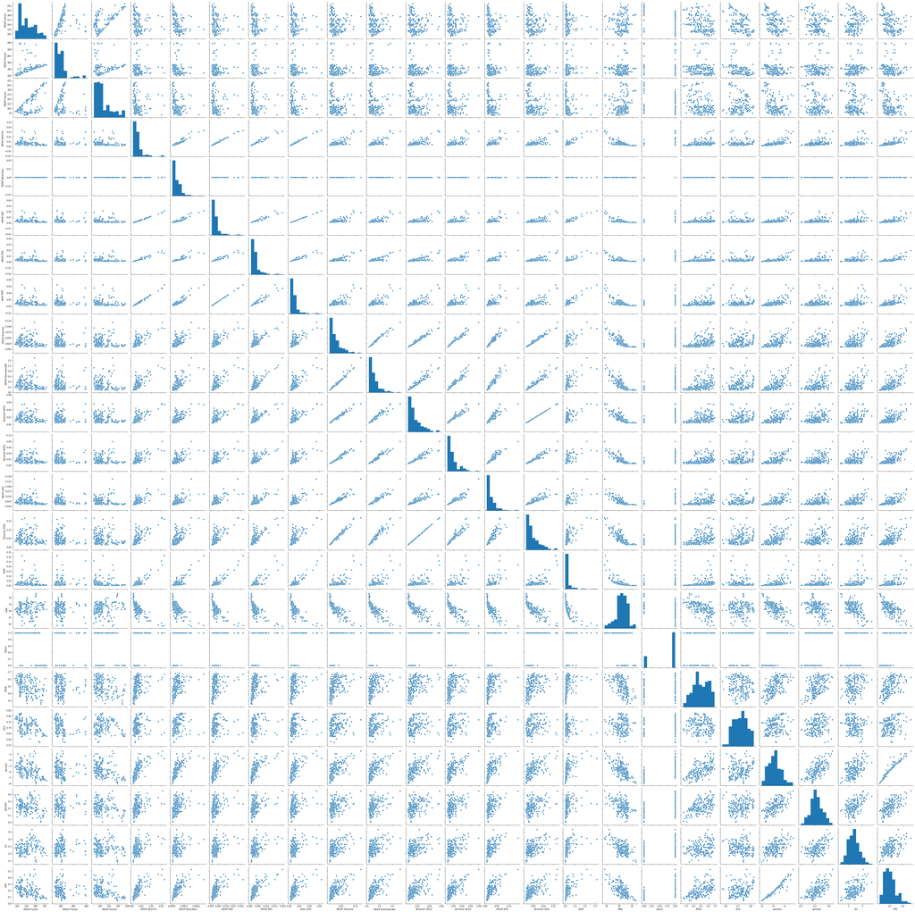

```python
sns.pairplot(Data)
```

We can see many pattern from just eyeballing the entire pairplot. For example, there are many similarly correlated features which may cause redundencies while running various models. Hence, we need to dive deeper and look into which similar features can be eliminated. Next we'll look at box plots to get an overview of the outliers.

```python
Data.corr()
```

|  | MDVP:Fo(Hz) | MDVP:Fhi(Hz) | MDVP:Flo(Hz) | MDVP:Jitter(%) | MDVP:Jitter(Abs) | MDVP:RAP | MDVP:PPQ | Jitter:DDP | MDVP:Shimmer | MDVP:Shimmer(dB) | ... | Shimmer:DDA | NHR | HNR | status | RPDE | DFA | spread1 | spread2 | D2 | PPE |
| --- | --- | --- | --- | --- | --- | --- | --- | --- | --- | --- | --- | --- | --- | --- | --- | --- | --- | --- | --- | --- | --- |
| MDVP:Fo(Hz) | 1.000000 | 0.400985 | 0.596546 | -0.118003 | -0.382027 | -0.076194 | -0.112165 | -0.076213 | -0.098374 | -0.073742 | ... | -0.094732 | -0.021981 | 0.059144 | -0.383535 | -0.383894 | -0.446013 | -0.413738 | -0.249450 | 0.177980 | -0.372356 |
| MDVP:Fhi(Hz) | 0.400985 | 1.000000 | 0.084951 | 0.102086 | -0.029198 | 0.097177 | 0.091126 | 0.097150 | 0.002281 | 0.043465 | ... | -0.003733 | 0.163766 | -0.024893 | -0.166136 | -0.112404 | -0.343097 | -0.076658 | -0.002954 | 0.176323 | -0.069543 |
| MDVP:Flo(Hz) | 0.596546 | 0.084951 | 1.000000 | -0.139919 | -0.277815 | -0.100519 | -0.095828 | -0.100488 | -0.144543 | -0.119089 | ... | -0.150737 | -0.108670 | 0.210851 | -0.380200 | -0.400143 | -0.050406 | -0.394857 | -0.243829 | -0.100629 | -0.340071 |
| MDVP:Jitter(%) | -0.118003 | 0.102086 | -0.139919 | 1.000000 | 0.935714 | 0.990276 | 0.974256 | 0.990276 | 0.769063 | 0.804289 | ... | 0.746635 | 0.906959 | -0.728165 | 0.278220 | 0.360673 | 0.098572 | 0.693577 | 0.385123 | 0.433434 | 0.721543 |
| MDVP:Jitter(Abs) | -0.382027 | -0.029198 | -0.277815 | 0.935714 | 1.000000 | 0.922911 | 0.897778 | 0.922913 | 0.703322 | 0.716601 | ... | 0.697170 | 0.834972 | -0.656810 | 0.338653 | 0.441839 | 0.175036 | 0.735779 | 0.388543 | 0.310694 | 0.748162 |
| MDVP:RAP | -0.076194 | 0.097177 | -0.100519 | 0.990276 | 0.922911 | 1.000000 | 0.957317 | 1.000000 | 0.759581 | 0.790652 | ... | 0.744919 | 0.919521 | -0.721543 | 0.266668 | 0.342140 | 0.064083 | 0.648328 | 0.324407 | 0.426605 | 0.670999 |
| MDVP:PPQ | -0.112165 | 0.091126 | -0.095828 | 0.974256 | 0.897778 | 0.957317 | 1.000000 | 0.957319 | 0.797826 | 0.839239 | ... | 0.763592 | 0.844604 | -0.731510 | 0.288698 | 0.333274 | 0.196301 | 0.716489 | 0.407605 | 0.412524 | 0.769647 |
| Jitter:DDP | -0.076213 | 0.097150 | -0.100488 | 0.990276 | 0.922913 | 1.000000 | 0.957319 | 1.000000 | 0.759555 | 0.790621 | ... | 0.744901 | 0.919548 | -0.721494 | 0.266646 | 0.342079 | 0.064026 | 0.648328 | 0.324377 | 0.426556 | 0.671005 |
| MDVP:Shimmer | -0.098374 | 0.002281 | -0.144543 | 0.769063 | 0.703322 | 0.759581 | 0.797826 | 0.759555 | 1.000000 | 0.987258 | ... | 0.987626 | 0.722194 | -0.835271 | 0.367430 | 0.447424 | 0.159954 | 0.654734 | 0.452025 | 0.507088 | 0.693771 |
| MDVP:Shimmer(dB) | -0.073742 | 0.043465 | -0.119089 | 0.804289 | 0.716601 | 0.790652 | 0.839239 | 0.790621 | 0.987258 | 1.000000 | ... | 0.963202 | 0.744477 | -0.827805 | 0.350697 | 0.410684 | 0.165157 | 0.652547 | 0.454314 | 0.512233 | 0.695058 |
| Shimmer:APQ3 | -0.094717 | -0.003743 | -0.150747 | 0.746625 | 0.697153 | 0.744912 | 0.763580 | 0.744894 | 0.987625 | 0.963198 | ... | 1.000000 | 0.716207 | -0.827123 | 0.347617 | 0.435242 | 0.151124 | 0.610967 | 0.402243 | 0.467265 | 0.645377 |
| Shimmer:APQ5 | -0.070682 | -0.009997 | -0.101095 | 0.725561 | 0.648961 | 0.709927 | 0.786780 | 0.709907 | 0.982835 | 0.973751 | ... | 0.960072 | 0.658080 | -0.813753 | 0.351148 | 0.399903 | 0.213873 | 0.646809 | 0.457195 | 0.502174 | 0.702456 |
| MDVP:APQ | -0.077774 | 0.004937 | -0.107293 | 0.758255 | 0.648793 | 0.737455 | 0.804139 | 0.737439 | 0.950083 | 0.960977 | ... | 0.896647 | 0.694019 | -0.800407 | 0.364316 | 0.451379 | 0.157276 | 0.673158 | 0.502188 | 0.536869 | 0.721694 |
| Shimmer:DDA | -0.094732 | -0.003733 | -0.150737 | 0.746635 | 0.697170 | 0.744919 | 0.763592 | 0.744901 | 0.987626 | 0.963202 | ... | 1.000000 | 0.716215 | -0.827130 | 0.347608 | 0.435237 | 0.151132 | 0.610971 | 0.402223 | 0.467261 | 0.645389 |
| NHR | -0.021981 | 0.163766 | -0.108670 | 0.906959 | 0.834972 | 0.919521 | 0.844604 | 0.919548 | 0.722194 | 0.744477 | ... | 0.716215 | 1.000000 | -0.714072 | 0.189429 | 0.370890 | -0.131882 | 0.540865 | 0.318099 | 0.470949 | 0.552591 |
| HNR | 0.059144 | -0.024893 | 0.210851 | -0.728165 | -0.656810 | -0.721543 | -0.731510 | -0.721494 | -0.835271 | -0.827805 | ... | -0.827130 | -0.714072 | 1.000000 | -0.361515 | -0.598736 | -0.008665 | -0.673210 | -0.431564 | -0.601401 | -0.692876 |
| status | -0.383535 | -0.166136 | -0.380200 | 0.278220 | 0.338653 | 0.266668 | 0.288698 | 0.266646 | 0.367430 | 0.350697 | ... | 0.347608 | 0.189429 | -0.361515 | 1.000000 | 0.308567 | 0.231739 | 0.564838 | 0.454842 | 0.340232 | 0.531039 |
| RPDE | -0.383894 | -0.112404 | -0.400143 | 0.360673 | 0.441839 | 0.342140 | 0.333274 | 0.342079 | 0.447424 | 0.410684 | ... | 0.435237 | 0.370890 | -0.598736 | 0.308567 | 1.000000 | -0.110950 | 0.591117 | 0.479905 | 0.236931 | 0.545886 |
| DFA | -0.446013 | -0.343097 | -0.050406 | 0.098572 | 0.175036 | 0.064083 | 0.196301 | 0.064026 | 0.159954 | 0.165157 | ... | 0.151132 | -0.131882 | -0.008665 | 0.231739 | -0.110950 | 1.000000 | 0.195668 | 0.166548 | -0.165381 | 0.270445 |
| spread1 | -0.413738 | -0.076658 | -0.394857 | 0.693577 | 0.735779 | 0.648328 | 0.716489 | 0.648328 | 0.654734 | 0.652547 | ... | 0.610971 | 0.540865 | -0.673210 | 0.564838 | 0.591117 | 0.195668 | 1.000000 | 0.652358 | 0.495123 | 0.962435 |
| spread2 | -0.249450 | -0.002954 | -0.243829 | 0.385123 | 0.388543 | 0.324407 | 0.407605 | 0.324377 | 0.452025 | 0.454314 | ... | 0.402223 | 0.318099 | -0.431564 | 0.454842 | 0.479905 | 0.166548 | 0.652358 | 1.000000 | 0.523532 | 0.644711 |
| D2 | 0.177980 | 0.176323 | -0.100629 | 0.433434 | 0.310694 | 0.426605 | 0.412524 | 0.426556 | 0.507088 | 0.512233 | ... | 0.467261 | 0.470949 | -0.601401 | 0.340232 | 0.236931 | -0.165381 | 0.495123 | 0.523532 | 1.000000 | 0.480585 |
| PPE | -0.372356 | -0.069543 | -0.340071 | 0.721543 | 0.748162 | 0.670999 | 0.769647 | 0.671005 | 0.693771 | 0.695058 | ... | 0.645389 | 0.552591 | -0.692876 | 0.531039 | 0.545886 | 0.270445 | 0.962435 | 0.644711 | 0.480585 | 1.000000 |

23 rows × 23 columns

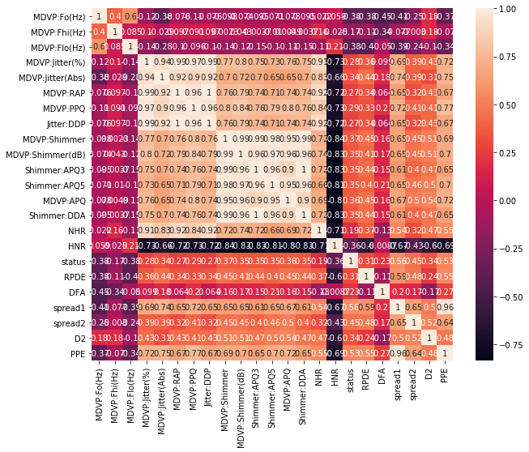

```python
cor = Data.corr()
plt.subplots(figsize=(10,8))
sns.heatmap(cor, annot=True)
```

```python
# correlation coefficient values in each attributes.
corr_values=Data.corr()['status']
corr_values.abs().sort_values(ascending=False)
```

```
status              1.000000
spread1             0.564838
PPE                 0.531039
spread2             0.454842
MDVP:Fo(Hz)         0.383535
MDVP:Flo(Hz)        0.380200
MDVP:Shimmer        0.367430
MDVP:APQ            0.364316
HNR                 0.361515
Shimmer:APQ5        0.351148
MDVP:Shimmer(dB)    0.350697
Shimmer:APQ3        0.347617
Shimmer:DDA         0.347608
D2                  0.340232
MDVP:Jitter(Abs)    0.338653
RPDE                0.308567
MDVP:PPQ            0.288698
MDVP:Jitter(%)      0.278220
MDVP:RAP            0.266668
Jitter:DDP          0.266646
DFA                 0.231739
NHR                 0.189429
MDVP:Fhi(Hz)        0.166136
Name: status, dtype: float64
```

We will drop the below columns from our features are they are highly similar.  
MDVP:RAP 0.266668  
Shimmer:APQ3 0.347617  
MDVP:Shimmer(dB) 0.350697  
Shimmer:APQ5 0.351148  
HNR 0.361515  
MDVP:APQ 0.364316

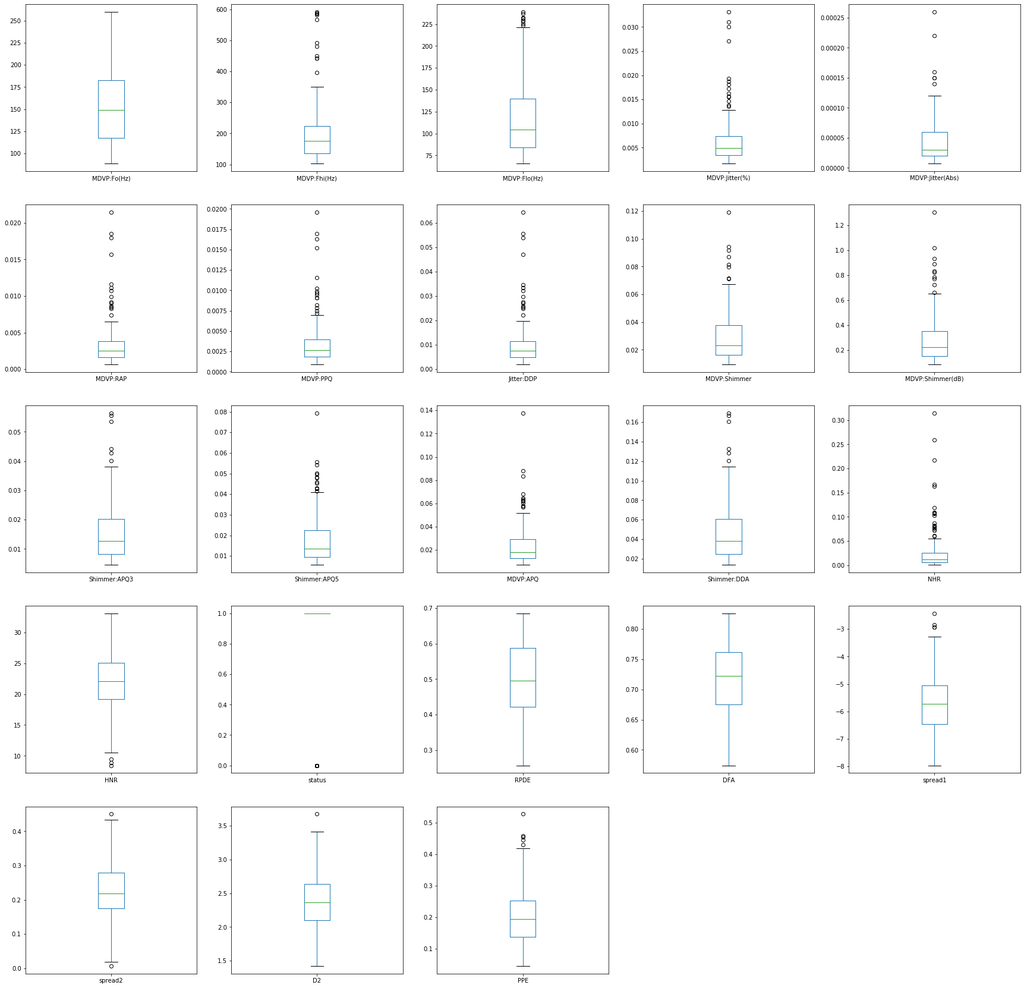

```python
Data.plot(kind='box', subplots=True, layout=(5,5), sharex=False, sharey=False, figsize=(30, 30))
plt.show()
```

There are many outliers in some of the features, this can prove to increase errors in some models. However, it is good to keep this in view for now.

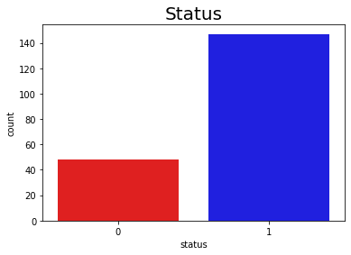

```python
sns.countplot(x="status",data=Data,palette=["Red","Blue"])
plt.title("Status",size=20)
plt.show()
```

The given data is more representative of status = 1 which may cause overfitting in our models. Ideally, this should be balanced.

```python
#Establishing features by dropping highly similar columns,
#Also splitting the status column from the selected features.

y=Data['status']
cols=['MDVP:RAP','Shimmer:APQ3','MDVP:Shimmer(dB)','Shimmer:APQ5','HNR','MDVP:APQ','name','status']
x1=Data.drop(cols,axis=1)

from scipy.stats import zscore
x  = x1.apply(zscore)  # convert all attributes to Z scale for normalizing the different units of dimension

x
```

|  | MDVP:Fo(Hz) | MDVP:Fhi(Hz) | MDVP:Flo(Hz) | MDVP:Jitter(%) | MDVP:Jitter(Abs) | MDVP:PPQ | Jitter:DDP | MDVP:Shimmer | Shimmer:DDA | NHR | RPDE | DFA | spread1 | spread2 | D2 | PPE |
| --- | --- | --- | --- | --- | --- | --- | --- | --- | --- | --- | --- | --- | --- | --- | --- | --- |
| 0 | -0.829300 | -0.436165 | -0.952037 | 0.334914 | 0.749759 | 0.760800 | 0.131755 | 0.745985 | 0.607532 | -0.067893 | -0.807838 | 1.760814 | 0.801323 | 0.480477 | -0.210531 | 0.868886 |
| 1 | -0.770972 | -0.530974 | -0.057721 | 0.715418 | 1.037674 | 1.276809 | 0.452684 | 1.681731 | 1.548254 | -0.137843 | -0.387524 | 1.837562 | 1.479853 | 1.311185 | 0.275077 | 1.803605 |
| 2 | -0.909476 | -0.723168 | -0.109875 | 0.884991 | 1.325589 | 1.585687 | 0.721813 | 1.202693 | 1.175323 | -0.291633 | -0.662075 | 1.942048 | 1.141445 | 1.017682 | -0.103629 | 1.402661 |
| 3 | -0.909622 | -0.649092 | -0.114229 | 0.775389 | 1.325589 | 1.284076 | 0.577677 | 1.340396 | 1.340229 | -0.280719 | -0.613134 | 1.832380 | 1.440945 | 1.293840 | 0.062145 | 1.806954 |
| 4 | -0.925657 | -0.606245 | -0.130608 | 1.368893 | 1.901418 | 2.047187 | 1.096793 | 1.836448 | 1.899461 | -0.178026 | -0.783021 | 1.909364 | 1.780940 | 0.096195 | -0.130026 | 2.267082 |
| ... | ... | ... | ... | ... | ... | ... | ... | ... | ... | ... | ... | ... | ... | ... | ... | ... |
| 190 | 0.483467 | 0.371185 | -0.508265 | -0.337173 | -0.401899 | -0.311189 | -0.227459 | 0.593395 | 0.759930 | 0.069278 | -0.483208 | -1.090704 | -0.785527 | -1.256837 | 0.721944 | -0.817703 |
| 191 | 1.339202 | 0.612690 | -0.618218 | -0.120037 | -0.401899 | -0.191272 | 0.002258 | -0.116922 | 0.037108 | -0.167360 | -0.644916 | -0.631503 | -0.469859 | -1.168475 | 1.054135 | -0.418929 |
| 192 | 0.495578 | 0.470104 | -0.968393 | 1.526058 | 1.037674 | 0.797139 | 0.992069 | -0.352453 | -0.294679 | 2.041513 | -0.877441 | -1.130853 | -1.014154 | -0.818079 | 0.780338 | -0.832410 |
| 193 | 1.078761 | 2.190044 | -0.954180 | 0.243924 | -0.113985 | 0.164847 | 0.131755 | -0.358834 | -0.297970 | 1.175327 | -0.456374 | -1.343323 | -0.974960 | -0.229066 | -0.637003 | -0.926105 |
| 194 | 1.454817 | 0.692246 | -0.883481 | -0.113833 | -0.401899 | -0.100425 | -0.120483 | -0.577883 | -0.533645 | 0.474590 | -0.344660 | -0.973698 | -0.036471 | -0.430853 | 0.454802 | -0.645055 |

195 rows × 16 columns

```python
y
```

```
0      1
1      1
2      1
3      1
4      1
      ..
190    0
191    0
192    0
193    0
194    0
Name: status, Length: 195, dtype: int64
```

### Splitting the into training and test

```python
train_size=0.70
test_size=0.30
seed=5

from sklearn.model_selection import train_test_split
x_train,x_test,y_train,y_test=train_test_split(x,y,train_size=train_size,test_size=test_size,random_state=seed)
```

### Running Classifiers

```python
from sklearn.linear_model import LogisticRegression
from sklearn.neighbors import KNeighborsClassifier
n_neighbors=5
from sklearn.svm import SVC
from sklearn.tree import DecisionTreeClassifier
from sklearn.naive_bayes import GaussianNB
from sklearn.model_selection import KFold
from sklearn.model_selection import cross_val_score

models=[]
models.append(('LogisticRegression',LogisticRegression()))
models.append(('knn',KNeighborsClassifier(n_neighbors=n_neighbors)))
models.append(('SVC',SVC()))
models.append(("Decision Tree",DecisionTreeClassifier()))
models.append(('Naive Bayes',GaussianNB()))

# Evaluating Each model with a cross validation to run the model for multiple iterations

names=[]
predictions=[]
acc='accuracy'
for name,model in models:
    result=cross_val_score(model,x_train,y_train,cv=3,scoring=acc)
    predictions.append(result)
    names.append(name)
    prt ="%s Mean Accuracy of 3 fold cross validation: %f "%(name,result.mean())
    print(prt)
```

```
LogisticRegression Mean Accuracy of 3 fold cross validation: 0.852979
knn Mean Accuracy of 3 fold cross validation: 0.882609
SVC Mean Accuracy of 3 fold cross validation: 0.867472
Decision Tree Mean Accuracy of 3 fold cross validation: 0.845411
Naive Bayes Mean Accuracy of 3 fold cross validation: 0.735266
```

KNN has the highest accuracy scores and hence is the strong learner in this group of classifiers. We can select KNN to be the meta classifier for the stacking below.

### Stacking Classifier

```python
from sklearn import model_selection
from mlxtend.classifier import StackingClassifier
from sklearn.neighbors import KNeighborsClassifier
from sklearn.tree import DecisionTreeClassifier
from sklearn.naive_bayes import GaussianNB
from sklearn.linear_model import LogisticRegression

clf1 = KNeighborsClassifier(n_neighbors=5)
clf2 = DecisionTreeClassifier()
clf3 = GaussianNB()
lr   = LogisticRegression()
sclf = StackingClassifier(classifiers=[clf1, clf2, clf3], meta_classifier=clf1)

print('3-fold cross validation:\n')

for clf, label in zip([lr, clf2, clf3, sclf], ['LogisticRegression',
                                               'Decision Tree Classifier',
                                               'Naive Bayes',
                                               'StackingClassifier']):

    scores = model_selection.cross_val_score(clf, x, y, cv=3, scoring='accuracy')
    print("Accuracy: %0.2f (+/- %0.2f) [%s]"
          % (scores.mean(), scores.std(), label))
```

```
3-fold cross validation:

Accuracy: 0.84 (+/- 0.04) [LogisticRegression]
Accuracy: 0.78 (+/- 0.06) [Decision Tree Classifier]
Accuracy: 0.72 (+/- 0.03) [Naive Bayes]
Accuracy: 0.85 (+/- 0.06) [StackingClassifier]
```

It seems like choosing KNN as meta classifier for stacking (or any other meta classifier for that case) does not drastically improve the accuracy. This could be point towards overfitting (as we already know the dataset is unbalanced towards status =1). Another reasons could be that there isn't sufficient diversity in the data for stacking to really outshine the individual classification. We should hence move on to further Ensemble techniques.

### Applying Ensemble

```python
# Libraries for Boosting
from sklearn.ensemble import AdaBoostClassifier
from sklearn.ensemble import GradientBoostingClassifier
# Library for Bagging
from sklearn.ensemble import RandomForestClassifier

ensembles=[]
ensembles.append(('AdaBoost',AdaBoostClassifier()))
ensembles.append(('GradBoost',GradientBoostingClassifier()))
ensembles.append(('RandForest',RandomForestClassifier(n_estimators=10)))

# Evaluating the accuracy of each Ensemble Techinique
results=[]
names=[]
for name,model in ensembles:
    fold=KFold(n_splits=10)
    result=cross_val_score(model,x_train,y_train,cv=fold,scoring=acc)
    results.append(result)
    names.append(name)
    prnt="%s Accuracy: %f "%(name,result.mean())
    print(prnt)
```

```
AdaBoost Accuracy: 0.830769
GradBoost Accuracy: 0.897802
RandForest Accuracy: 0.881868
```

We can see that the accuracy of Gradient Boosting is the highest, hence it is safe to say our ensemble trial has improved the accuracy as compared to the previous attained accuracies (KNN or any other indivudual/stacked classification model).

Based on the fact that gradient boosting has out performed other models, we should select it as the best one to perform our predictive detection for parkinsons disease with the given data.

### We finalize the Gradient Boosting Classification as the best model for detection parkinsons disease based on this dataset

```python
from sklearn.metrics import confusion_matrix
from sklearn.metrics import accuracy_score


model=GradientBoostingClassifier(n_estimators=1000)
model.fit(x_train,y_train)


y_pred=model.predict(x_test)
y_pred_train=model.predict(x_train)
```

```python
accuracy_mean=accuracy_score(y_train,y_pred_train)
confusion=confusion_matrix(y_train,y_pred_train)
print("Mean Accuracy for training set:",accuracy_mean)
print("Confusion matrix for training set:\n",confusion)

accuracy_mean=accuracy_score(y_test,y_pred)
confusion=confusion_matrix(y_test,y_pred)
print("Mean accuracy testing set:",accuracy_mean)
print("Confusion matrix testing set:\n",confusion)
```

```
Mean Accuracy for training set: 1.0
Confusion matrix for training set:
 [[ 32   0]
 [  0 104]]
Mean accuracy testing set: 0.9152542372881356
Confusion matrix testing set:
 [[11  5]
 [ 0 43]]
```

We have achieved 91.5% accuracy (multiple iteration of n_estimators) with gradient boosting technique. It could be that the iterative approach of gradient boosting (which is adding weak learner trees while minimizing the loss function one step at a time) has proved to be a great fit for this data. Also, since the data was unbalanced towards status = 1, a big number of n_estimators can offset that as gradient boosting is quite robust to over-fitting. In contrast to adaboost (about 83% accuracy), gradient boost has proven to be better in this case due to it's gradient optimization rather than voting weights. However, if there were less outliers in the data (or the outliers had been cleaned) gradient boost would perform better as those outliers would not compound over sequential iterations.